# Many Outcomes

Session 10

2026-11-10

## One question, many measurements

- A study with many outcomes can answer two different questions:
  - Which outcomes moved? Test each outcome, and adjust for the number of tests.
  - Did the construct move? Combine the outcomes into one index, and test it once.
- Every index assumes a **measurement model**: how the outcomes relate to the construct. The weights follow from the model.

## Where many outcomes come from in AI evaluation

- Several benchmarks or task families.
- Rubric dimensions: accuracy, clarity, tone, safety.
- Several judges, or human and judge scores of the same output.
- Subgroups of users or items.
- Prompt variants, seeds, and several models compared with one baseline.
- Each of these is a **family** of tests.
- Very rarely do you only have one thing you care about measuring in only one way.

## How fast false positives accumulate

- Lecture 06: $K$ independent tests at 5% give at least one false positive with probability $1 - 0.95^K$.
- Correlated outcomes inflate it less, because their tests reject together.

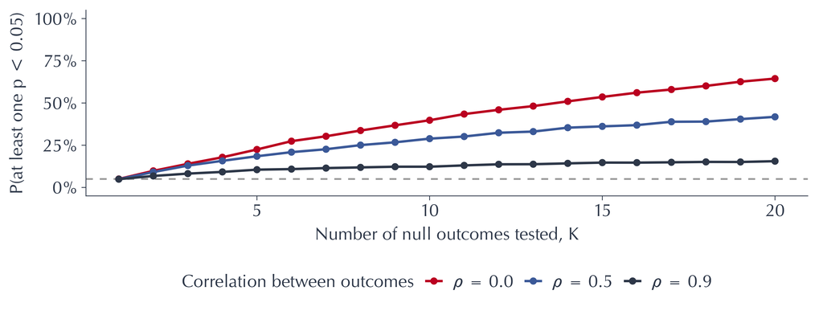

## A family is the set of tests behind one claim

- A correction controls errors **within a family**: the tests that together support one claim.
  - “The assistant improves essays” rests on all eight rubric dimensions: one family.
  - “The assistant helps non-native speakers more” rests on the subgroup tests: a second family.
- A single primary hypothesis is a family of one. It needs no correction.
- Lecture 07’s PAP talked through how to deal with this for a single primary hypothesis.
- Today: we expand beyond a single measure and think about multiple measures within a family and whether to combine them into an index.

# Adjusting the tests

## Two error rates

- Of $K$ hypotheses, the procedure rejects $R$. Of those, $V$ are true nulls.

$$\text{FWER} = \Pr(V \geq 1), \qquad \text{FDR} = \mathbb{E}\!\left[\frac{V}{\max(R, 1)}\right]$$

- FWER protects every individual claim.
  - Even one false claim is costly: a safety finding, or the effect on a named outcome.
- FDR protects the share of claims that are wrong.
  - To screen many candidates: which of 50 prompt variants to follow up.
- $\text{FDR} \leq \text{FWER}$, so FDR control rejects more.
  - FWER control is more conservative. It accepts fewer discoveries in exchange for fewer false ones.

## Bonferroni and Holm

- Bonferroni: reject $H_k$ if $p_k \leq \alpha / K$.
- Holm: sort the p-values. Reject from the smallest up, until the first one above its threshold:

$$p_{(j)} > \frac{\alpha}{K - j + 1}$$

- Both control FWER at $\alpha$ under any dependence. Holm rejects at least as much.
- Both are conservative with correlated outcomes.

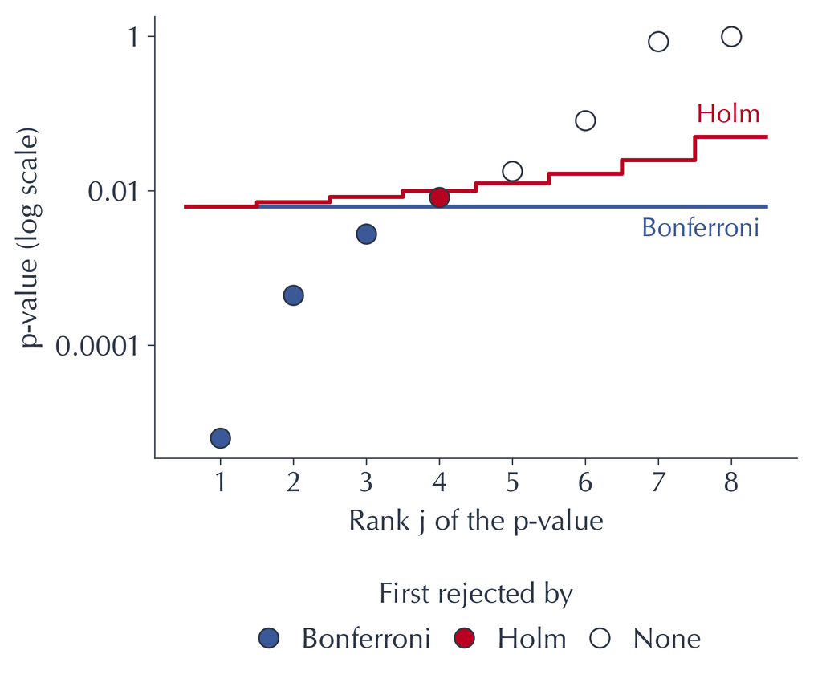

[Holm (1979), “A Simple Sequentially Rejective Multiple Test Procedure,” *Scandinavian Journal of Statistics*, 6(2).](https://www.jstor.org/stable/4615733)

## Using the dependence: resampling step-down

- Holm’s thresholds assume the worst case. The **joint** null distribution of the $t$-statistics gives exact ones.
- Re-randomize $Z$ (Westfall–Young) or bootstrap (Romano–Wolf), and step down:

$$\tilde p_{(j)} = \Pr\nolimits^*\Big(\max_{k \geq j} |t^*_{(k)}| \geq |t_{(j)}|\Big)$$

- Correlated outcomes raise the thresholds, so it rejects more at the same FWER.
- List, Shaikh & Xu (2019) extend it to subgroups and treatments.

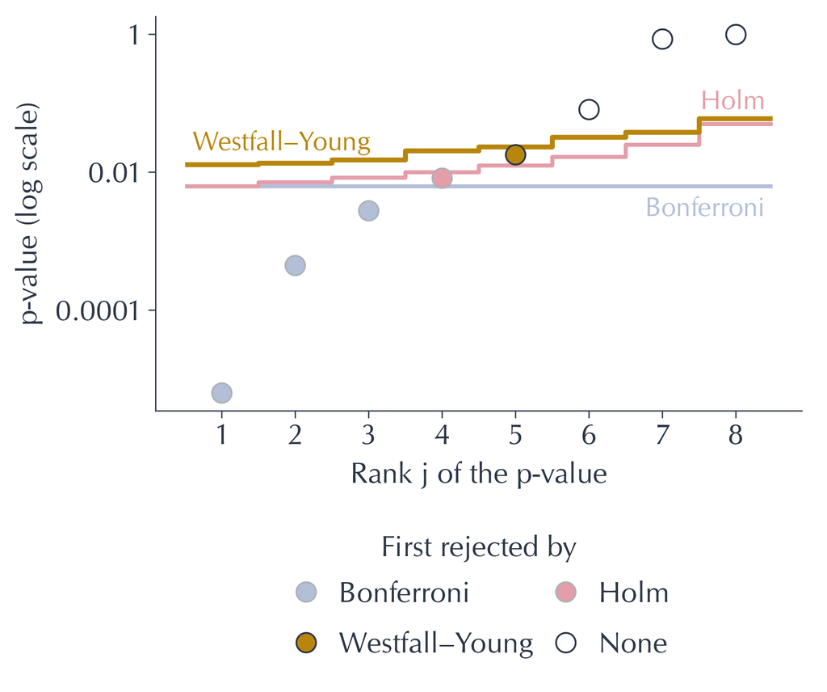

[Romano & Wolf (2005), *Econometrica*, 73(4).](https://doi.org/10.1111/j.1468-0262.2005.00615.x) [List, Shaikh & Xu (2019), *Experimental Economics*, 22(4).](https://doi.org/10.1007/s10683-018-09597-5)

## Controlling the false discovery rate

- Benjamini–Hochberg: reject $H_{(1)}, \dots, H_{(j^*)}$, stepping up from the largest p-value:

$$j^* = \max\Big\{ j : p_{(j)} \leq \frac{j}{K}\,\alpha \Big\}$$

- Valid under positive dependence, the usual case for one treatment’s outcomes.
- Benjamini–Yekutieli: divide $\alpha$ by $\sum_j 1/j$ for any dependence.
- Anderson (2008) reports **sharpened q-values**.

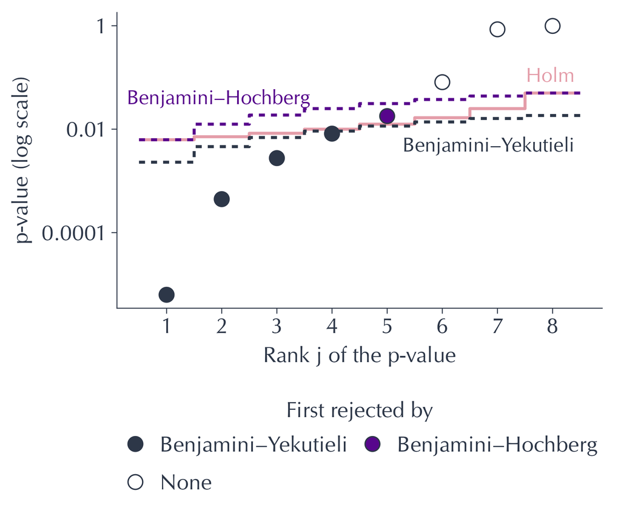

[Benjamini & Hochberg (1995), *JRSS-B*, 57(1).](https://doi.org/10.1111/j.2517-6161.1995.tb02031.x) [Benjamini & Yekutieli (2001), *Annals of Statistics*, 29(4).](https://doi.org/10.1214/aos/1013699998) Benjamini, Krieger & Yekutieli (2006), *Biometrika*, 93(3).

## Simulation: power of each correction

- 200 participants, 8 rubric dimensions. Three dimensions improve by 0.4 SD, five do not move.

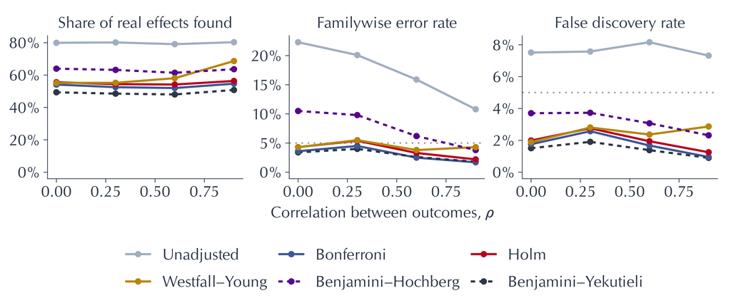

## Correcting the winner’s estimate

- Lecture 07: the best of $k$ estimates is inflated. The fix conditions on the selection.
- The winner $\hat k$ beat every rival, so $X_{\hat k} \geq L$. With estimates correlated $\rho$:

$$L = \max_{j \neq \hat k} \frac{X_j - \rho X_{\hat k}}{1 - \rho}$$

- $X_{\hat k}$ is normal **truncated at $L$**. Solve $F_\tau(X_{\hat k}) = \tfrac12$ for a median-unbiased estimate, and at $\tfrac{\alpha}{2}$, $1 - \tfrac{\alpha}{2}$ for the interval. With $\bar\Phi = 1 - \Phi$:

$$F_\tau(X_{\hat k}) = 1 - \frac{\bar\Phi\big((X_{\hat k} - \tau)/\sigma\big)}{\bar\Phi\big((L - \tau)/\sigma\big)}$$

- 10 variants, all truly +2. Naive: median +5.2, coverage 86%. Conditional: median +1.9, coverage 95%, 2.1× as wide. AKM’s **hybrid** interval narrows it.

[Andrews, Kitagawa & McCloskey (2024), “Inference on Winners,” *QJE*, 139(1).](https://doi.org/10.1093/qje/qjad043)

# Building an index

## An index changes the hypothesis

Separate targets

[figure not shown]

Measurements of one construct

[figure not shown]

- An index is a weighted sum of standardized outcomes:

$$I_i = \sum_k w_k \tilde y_{ik}, \qquad \tilde y_{ik} = \frac{y_{ik} - \bar y^{(0)}_k}{s^{(0)}_k}$$

- One test, no correction. Each index below is the right weighting for one measurement model (lecture 04).

## Equal weights: the mean-effects index

[figure not shown]

- Orient every outcome so higher is better, standardize by the control group, and average:

$$I_i = \frac{1}{K}\sum_{k=1}^{K} \tilde y_{ik}$$

- Model: every outcome loads equally on $\eta$. Errors are independent with equal variance (parallel measures).
- Under that model, the average is the best linear estimate of $\eta$.
- Easy to explain and to register. Redundant outcomes count several times: four judge scores of one quality get four votes.

[Kling, Liebman & Katz (2007), “Experimental Analysis of Neighborhood Effects,” *Econometrica*, 75(1).](https://doi.org/10.1111/j.1468-0262.2007.00733.x)

## Inverse-covariance weights: Anderson (2008)

[figure not shown]

- Weight by the inverse covariance $\hat\Sigma^{-1}$ of the standardized outcomes in the control group:

$$I_i = \frac{\mathbf{1}^\top \hat\Sigma^{-1} \tilde y_i}{\mathbf{1}^\top \hat\Sigma^{-1} \mathbf{1}}$$

- Model: equal loadings on $\eta$. Errors may be correlated: $Y_3$ and $Y_4$ are scored by the same LLM judge, and share its biases $M$.
- These are then the GLS weights: the minimum-variance linear estimate of $\eta$.
- An outcome that duplicates others gets less weight.

[Anderson (2008), “Multiple Inference and Gender Differences in the Effects of Early Intervention,” *JASA*, 103(484).](https://are.berkeley.edu/~mlanderson/pdf/Preschool_JASA.pdf)

## Principal components

[figure not shown]

- Weight by the first eigenvector of the correlation matrix $\hat R$:

$$I_i = v_1^\top \tilde y_i, \qquad v_1 = \arg\max_{\|v\| = 1} v^\top \hat R\, v$$

- Model: one factor, unequal loadings $\lambda_k$, independent errors of equal variance. Then $v_1 \propto \lambda$.
- The weights follow shared variance. Biases shared by one judge model can dominate the first component.
- Register the fitting sample, the sign, and the number of components.

A factor model, or IRT for binary items, estimates the loadings and error variances directly. [Fu & Green (2026), arXiv:2505.21909.](https://arxiv.org/abs/2505.21909)

## Simulation: three indices, one study

- Judge 1–4: one LLM judge scores four rubric dimensions, so they share its biases. Human 1–4: humans score the other four separately. The assistant raises essay quality $\eta$ by 0.2.

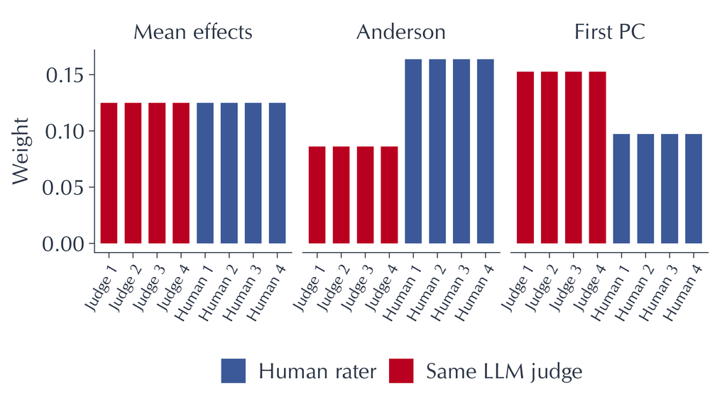

| Index | Effect | Power |
| --- | --- | --- |
| Mean effects | 0.30 | 55% |
| Anderson | 0.33 | 61% |
| First PC | 0.27 | 47% |

Effect in control-group SDs of each index. 1000 simulated studies.

## Weights from a target: the surrogate index

[figure not shown]

- Goal: the effect on a long-run outcome $Y$ (the final exam, 90-day retention) before $Y$ is observed.
- In an observational sample $O$ with both $S$ and $Y$, fit $\hat g(s) = \hat{\mathbb{E}}[Y \mid S = s, O]$.
- In the experiment, use $\hat g(S_i)$ as the outcome:

$$\hat\tau_Y = \frac{1}{n_1}\sum_{Z_i = 1} \hat g(S_i) - \frac{1}{n_0}\sum_{Z_i = 0} \hat g(S_i)$$

- The weights come from predicting $Y$. The target fixes them.

[Athey, Chetty, Imbens & Kang (2019), “The Surrogate Index: Combining Short-Term Proxies to Estimate Long-Term Treatment Effects More Rapidly and Precisely,” NBER WP 26463.](https://www.nber.org/papers/w26463)

## What the surrogate index assumes

[figure not shown]

- Surrogacy: $Z \perp Y \mid S$. The whole effect on $Y$ passes through $S$. It fails with
  - a direct path $Z \to Y$
  - a shared cause $U$ of $S$ and $Y$: conditioning on $S$ opens $Z \to S \leftarrow U \to Y$.
- Comparability: $Y \mid S$ has the same distribution in the observational sample and the experiment.
- *Failure:* an assistant that writes the answers raises rubric scores $S$ and lowers exam results $Y$. The index predicts a gain.
- Lecture 06’s surrogate labels use a simple proxy. The surrogate *index* combines many proxies to better represent the actual target.

## Aggregating across benchmarks

| Model | Math | Code | Safety | Writing | Mean score | Mean win rate |
| --- | --- | --- | --- | --- | --- | --- |
| A | 90 | 90 | 40 | 40 | 65.0 | 0.38 |
| B | 70 | 70 | 70 | 70 | 70.0 | 0.50 |
| C | 95 | 95 | 30 | 50 | 67.5 | 0.62 |

- A leaderboard is an index over benchmarks. By **mean score**, B wins. By **mean win rate** (HELM), the share of head-to-head comparisons won averaged over benchmarks, C wins.
- Rank-based rules are votes among benchmarks. Their rankings can change when a model is added or removed. More diverse benchmarks are less stable (Zhang & Hardt 2024).
- Register the aggregation rule with the benchmark list.

[Zhang & Hardt (2024), “Inherent Trade-Offs between Diversity and Stability in Multi-Task Benchmarks,” ICML.](https://arxiv.org/abs/2405.01719) [Liang et al. (2022), HELM.](https://arxiv.org/abs/2211.09110)

# Testing all outcomes jointly

## Is anything moving? Omnibus tests

- An index tests one weighted sum, and its weights define the construct. A **joint test** of all $K$ effects needs no weights. It asks whether any outcome moved: $\tau_1 = \dots = \tau_K = 0$.
- The Wald statistic uses the full covariance of the $K$ estimated effects:

$$W = \hat\tau^\top \hat V^{-1} \hat\tau, \qquad \hat V = \frac{S_1}{n_1} + \frac{S_0}{n_0}$$

- $S_z$ is the covariance matrix of the outcomes in arm $z$. Under the null, $W \approx \chi^2_K$.
- Randomization inference: under the sharp null, $Y_{ik}(1) = Y_{ik}(0)$ for every unit and outcome. Re-randomize $Z$, recompute $W$, and report the share of draws with $W^* \geq W$. This is exact in finite samples.

[Young (2019), “Channeling Fisher,” *QJE*.](https://doi.org/10.1093/qje/qjy029) [Caughey, Dafoe & Seawright (2017), “Nonparametric Combination (NPC),” *Political Analysis*.](https://doi.org/10.1093/pan/mpx013)

## Simulation: which test finds the effect

- 200 participants, half get a writing assistant. Essays are scored on 8 rubric dimensions, correlated $\rho = 0.3$. Effects are in control-SD units.

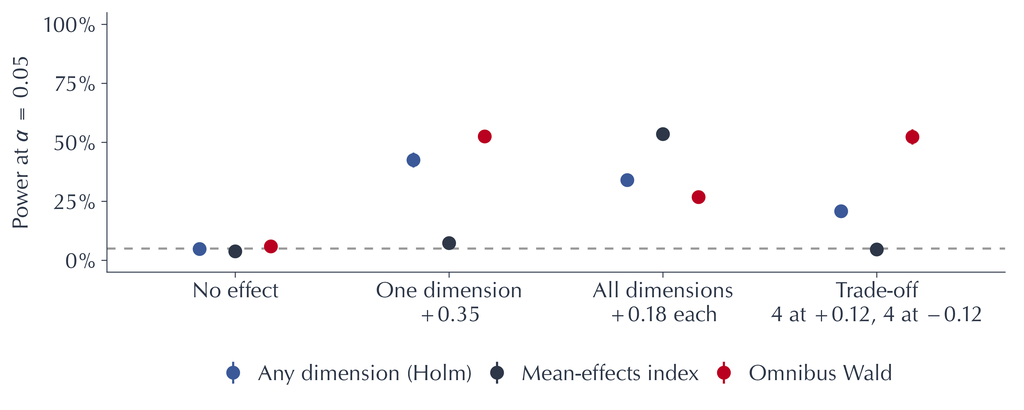

- The index wins when the effects share a sign. The omnibus test wins otherwise, because it uses the correlation between dimensions. Holm answers a narrower question: which dimension moved.

## Inverse regression

- Regress the treatment on all outcomes at once:

$$Z_i = \alpha + \beta^\top \tilde y_i + e_i$$

- Testing $\beta = 0$ asks whether the outcome vector differs between arms. For OLS this $F$ test is Hotelling’s $T^2$, an omnibus test.
- Each $\beta_k$ shows how outcome $k$ separates the arms, holding the other outcomes fixed.
- Zhang, Li & Ding (2025) develop this approach for causal inference with multiple outcomes.

[Zhang, Li & Ding (2025), “Inverse Regression for Causal Inference with Multiple Outcomes,” arXiv:2509.12587.](https://arxiv.org/abs/2509.12587)

# Other responses

## Partial pooling

- Model the $K$ effects as draws from one distribution:

$$\hat\tau_k \sim N(\tau_k, s_k^2), \qquad \tau_k \sim N(\mu, \sigma^2)$$

- Each estimate moves toward the common mean, the noisy ones most:

$$\tilde\tau_k = (1 - B_k)\,\hat\tau_k + B_k\,\hat\mu, \qquad B_k = \frac{s_k^2}{s_k^2 + \hat\sigma^2}$$

- The extreme estimates that drive false positives shrink most. The intervals come from the model, with no further correction.
- Assumption: the $K$ effects are exchangeable. This fits rubric dimensions, subgroups, or prompt variants on a common scale.

[Gelman, Hill & Yajima (2012), “Why We (Usually) Don’t Have to Worry About Multiple Comparisons,” *JREE*, 5(2).](https://sites.stat.columbia.edu/gelman/research/published/multiple2f.pdf)

## Matching the response to the question

- *This named outcome moved:* FWER control. Holm or Westfall–Young.
- *Most of these discoveries are real:* FDR control. Benjamini–Hochberg.
- *The construct moved:* an index, weighted by the measurement model you believe.
- *The long-run outcome moved:* a surrogate index, if surrogacy is credible.
- *Something moved:* an omnibus test.
- *The best arm is this much better:* fresh items, or winner’s-curse intervals.
- The method follows from the claim you want to make.

# Heterogeneous effects

## Subgroups: which null?

- With $G$ subgroups, there are $G$ effects $\tau_1, \dots, \tau_G$. Two different nulls:
  - No effect anywhere: $\tau_1 = \dots = \tau_G = 0$. A joint test, like the omnibus test.
  - No heterogeneity: $\tau_1 = \dots = \tau_G$. The effect may be large, but it is the same in every group.
- A significant effect in one group and not another is no evidence of heterogeneity. Test the difference:

$$\widehat{\mathrm{SE}}(\hat\tau_A - \hat\tau_B) = \sqrt{\widehat{\mathrm{SE}}(\hat\tau_A)^2 + \widehat{\mathrm{SE}}(\hat\tau_B)^2}$$

- Registered subgroups get a correction within their family. Unregistered subgroups are exploratory.

## Continuous moderators

- Lecture 06’s Lin estimator already interacts $Z$ with $X$. The interaction is the heterogeneity estimate:

$$Y_i = \alpha + \tau Z_i + \gamma X_i + \delta Z_i X_i + \varepsilon_i, \qquad \tau(x) = \tau + \delta x$$

- $\delta = 0$ is the no-heterogeneity null for $X$.
- The model assumes the effect changes **linearly** in $x$, and that both arms have data across the range of $x$.
- Check both: estimate the effect within bins of $X$ (e.g., terciles) and compare with the line.

[Hainmueller, Mummolo & Xu (2019), “How Much Should We Trust Estimates from Multiplicative Interaction Models?,” *Political Analysis*, 27(2).](https://doi.org/10.1017/pan.2018.46)

## The oracle regression

- If we saw each unit’s effect $\tau_i = Y_i(1) - Y_i(0)$, heterogeneity would be an ordinary regression:

$$\hat\beta = \arg\min_\beta \sum_i \big(\tau_i - X_i^\top \beta\big)^2$$

- Each unit reveals $Y_i(1)$ or $Y_i(0)$, never both. $\tau_i$ is never observed.
- We need an observable quantity whose regression on $X$ has the same target, $\tau(x) = \mathbb{E}[\tau_i \mid X_i = x]$.

## Robinson’s decomposition and the R-learner

- **Frisch–Waugh–Lovell:** the coefficient on $Z$ in $Y \sim Z + X$ is the regression of residualized $Y$ on residualized $Z$.
- **Robinson (1988)** extends this to effects that vary with $X$. With $m(x) = \mathbb{E}[Y \mid X = x]$ and $e(x) = \Pr(Z = 1 \mid X = x)$:

$$Y_i - m(X_i) = \big(Z_i - e(X_i)\big)\,\tau(X_i) + \varepsilon_i$$

- In an experiment $e = \tfrac12$ is known. Fit $\hat m$ on held-out folds. Then regress, with weights $(Z_i - e)^2$:

$$\tilde\tau_i = \frac{Y_i - \hat m(X_i)}{Z_i - e} \quad \text{on } X_i$$

- This is the oracle regression, with the observable $\tilde\tau_i$ in place of $\tau_i$: $\mathbb{E}[\tilde\tau_i \mid X_i] = \tau(X_i)$.

[Robinson (1988), *Econometrica*, 56(4).](https://doi.org/10.2307/1912705) [Nie & Wager (2021), “Quasi-Oracle Estimation of Heterogeneous Treatment Effects,” *Biometrika*, 108(2).](https://doi.org/10.1093/biomet/asaa076)

## Simulation: oracle and R-learner

- 400 participants. The assistant helps weaker writers more: $\tau(x) = 0.4 - 0.25x$, with $x$ the prior writing score in SDs.

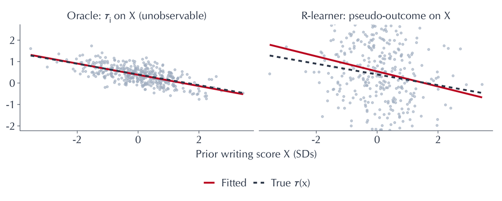

- Both regressions target $\tau(x)$. The pseudo-outcome is far noisier than $\tau_i$ (many points fall outside this window), so the R-learner needs more data for the same precision.

# Before session 11

## For next week

- Session 11 is a workshop on preliminary analysis, following your PAP.
- Bring as much as you can of:
  - the registered primary estimate, with its interval
  - each registered family, with its correction or index
  - the deviations so far, with the reason for each
  - some additional exploratory analyses worth running.
- Run the registered analysis first, before any exploratory analysis.

## Next week’s readings

- **Anderson (2008):** the inverse-covariance index and sharpened q-values, applied to three preschool experiments.
- **List, Shaikh & Xu (2019):** resampling-based FWER control for many outcomes, subgroups, and treatments.
- **Dehghani et al. (2021), “The Benchmark Lottery”:** how the choice of benchmarks and aggregation changes which model wins.

[Anderson (2008), *JASA*, 103(484).](https://are.berkeley.edu/~mlanderson/pdf/Preschool_JASA.pdf) [List, Shaikh & Xu (2019), *Experimental Economics*, 22(4).](https://doi.org/10.1007/s10683-018-09597-5) [Dehghani et al. (2021), arXiv:2107.07002.](https://arxiv.org/abs/2107.07002)